```python
#import packages (including linear_model)
import pandas as pd
import numpy as np
import seaborn as sns
import matplotlib.pyplot as plt
%matplotlib inline

#regression packages
import sklearn.linear_model as lm

#model validation
from sklearn.model_selection import train_test_split
from sklearn.model_selection import cross_val_score

#model evaluation
from sklearn.metrics import mean_squared_error
from sklearn.metrics import explained_variance_score

#statistical regression analysis
import statsmodels.api as sm
from statsmodels.formula.api import ols

from sklearn.ensemble import RandomForestRegressor #decision tree base regression. Diff from previous algorithm.
from sklearn.datasets import make_regression
from sklearn.preprocessing import normalize

from sklearn.preprocessing import StandardScaler, OneHotEncoder
from sklearn.compose import ColumnTransformer
from sklearn.pipeline import Pipeline

from sklearn.model_selection import train_test_split
from sklearn.impute import SimpleImputer

from sklearn.linear_model import LinearRegression
from sklearn.metrics import mean_squared_error, mean_absolute_error, r2_score
from sklearn.ensemble import RandomForestRegressor

#ignore warning
import warnings
warnings.filterwarnings("ignore")

# recursive feature selection (feature selection)
from sklearn.feature_selection import RFE

import statsmodels.api as sm
from statsmodels.formula.api import ols

#f_regression (feature selection)
from sklearn.feature_selection import f_regression
from sklearn.feature_selection import SelectKBest


pd.set_option('display.float_format', '{:.2f}'.format)
```

# Task 1: Data Import

## A. Load the dataset into a pandas DataFrame.

```python
# import data
stocks = pd.read_csv("data/finance.csv")
```

```python
stocks.head(2)
```

|  | PE_Ratio | Dividend_Yield | Beta | Market_Cap | Trading_Volume | EPS | Debt_to_Equity | ROE | Current_Ratio | Interest_Rate | GDP_Growth | Sector | Exchange | Rating | Stock_Price |
| --- | --- | --- | --- | --- | --- | --- | --- | --- | --- | --- | --- | --- | --- | --- | --- |
| 0 | 27.44 | 1.56 | 1.03 | 10120.68 | 1279001.12 | 5.62 | 0.47 | 15.86 | 1.41 | 3.13 | 1.63 | Consumer | AMEX | BB | 90.85 |
| 1 | 21.44 | 2.34 | 0.85 | 9914.20 | 851882.99 | 4.61 | 0.72 | 15.86 | 1.82 | 2.10 | 2.40 | Technology | NYSE | AA | 92.65 |

## B. Perform a basic inspection to understand the dimensions, data types, and the first few rows of the dataset.

```python
stocks.info() #information of the dataset.
```

```
<class 'pandas.core.frame.DataFrame'>
RangeIndex: 1971 entries, 0 to 1970
Data columns (total 15 columns):
 #   Column          Non-Null Count  Dtype
---  ------          --------------  -----
 0   PE_Ratio        1931 non-null   float64
 1   Dividend_Yield  1932 non-null   float64
 2   Beta            1931 non-null   float64
 3   Market_Cap      1932 non-null   float64
 4   Trading_Volume  1931 non-null   float64
 5   EPS             1971 non-null   float64
 6   Debt_to_Equity  1971 non-null   float64
 7   ROE             1971 non-null   float64
 8   Current_Ratio   1971 non-null   float64
 9   Interest_Rate   1971 non-null   float64
 10  GDP_Growth      1971 non-null   float64
 11  Sector          1931 non-null   object
 12  Exchange        1931 non-null   object
 13  Rating          1971 non-null   object
 14  Stock_Price     1971 non-null   float64
dtypes: float64(12), object(3)
memory usage: 231.1+ KB
```

```python
stocks.dtypes
```

```
PE_Ratio          float64
Dividend_Yield    float64
Beta              float64
Market_Cap        float64
Trading_Volume    float64
EPS               float64
Debt_to_Equity    float64
ROE               float64
Current_Ratio     float64
Interest_Rate     float64
GDP_Growth        float64
Sector             object
Exchange           object
Rating             object
Stock_Price       float64
dtype: object
```

```python
# Lowercase names
stocks.columns = stocks.columns.str.lower()
stocks.head(2)
```

|  | pe_ratio | dividend_yield | beta | market_cap | trading_volume | eps | debt_to_equity | roe | current_ratio | interest_rate | gdp_growth | sector | exchange | rating | stock_price |
| --- | --- | --- | --- | --- | --- | --- | --- | --- | --- | --- | --- | --- | --- | --- | --- |
| 0 | 27.44 | 1.56 | 1.03 | 10120.68 | 1279001.12 | 5.62 | 0.47 | 15.86 | 1.41 | 3.13 | 1.63 | Consumer | AMEX | BB | 90.85 |
| 1 | 21.44 | 2.34 | 0.85 | 9914.20 | 851882.99 | 4.61 | 0.72 | 15.86 | 1.82 | 2.10 | 2.40 | Technology | NYSE | AA | 92.65 |

```python
stocks.shape
```

```
(1971, 15)
```

```python
stocks.tail(2)
```

|  | pe_ratio | dividend_yield | beta | market_cap | trading_volume | eps | debt_to_equity | roe | current_ratio | interest_rate | gdp_growth | sector | exchange | rating | stock_price |
| --- | --- | --- | --- | --- | --- | --- | --- | --- | --- | --- | --- | --- | --- | --- | --- |
| 1969 | 14.48 | 1.58 | 1.05 | 11610.91 | 1195169.64 | 6.29 | 0.47 | 12.79 | 1.33 | 2.01 | 2.96 | Technology | NASDAQ | AA | 84.49 |
| 1970 | 14.42 | 2.30 | 0.83 | 7865.98 | 1019367.08 | 4.32 | 0.56 | 14.62 | 1.51 | 2.28 | 2.09 | NaN | NASDAQ_ | BB | 85.29 |

## C. What variables are numerical? Categorical?

```python
stocks.info()
```

```
<class 'pandas.core.frame.DataFrame'>
RangeIndex: 1971 entries, 0 to 1970
Data columns (total 15 columns):
 #   Column          Non-Null Count  Dtype
---  ------          --------------  -----
 0   pe_ratio        1931 non-null   float64
 1   dividend_yield  1932 non-null   float64
 2   beta            1931 non-null   float64
 3   market_cap      1932 non-null   float64
 4   trading_volume  1931 non-null   float64
 5   eps             1971 non-null   float64
 6   debt_to_equity  1971 non-null   float64
 7   roe             1971 non-null   float64
 8   current_ratio   1971 non-null   float64
 9   interest_rate   1971 non-null   float64
 10  gdp_growth      1971 non-null   float64
 11  sector          1931 non-null   object
 12  exchange        1931 non-null   object
 13  rating          1971 non-null   object
 14  stock_price     1971 non-null   float64
dtypes: float64(12), object(3)
memory usage: 231.1+ KB
```

```python
for col in stocks.columns:
    print(col,stocks[col].nunique())#Sector exchange and rating are considered categorical values everything else is a numercial value.
```

```
pe_ratio 1931
dividend_yield 1932
beta 1931
market_cap 1932
trading_volume 1931
eps 1971
debt_to_equity 1971
roe 1971
current_ratio 1971
interest_rate 1971
gdp_growth 1971
sector 8
exchange 6
rating 5
stock_price 1971
```

# Task 2: Data Exploration

## A. Use summary statistics and visualizations to understand the data distribution.

```python
stocks.describe()
```

|  | pe_ratio | dividend_yield | beta | market_cap | trading_volume | eps | debt_to_equity | roe | current_ratio | interest_rate | gdp_growth | stock_price |
| --- | --- | --- | --- | --- | --- | --- | --- | --- | --- | --- | --- | --- |
| count | 1931.00 | 1932.00 | 1931.00 | 1932.00 | 1931.00 | 1971.00 | 1971.00 | 1971.00 | 1971.00 | 1971.00 | 1971.00 | 1971.00 |
| mean | 19.93 | 2.00 | 1.01 | 10853.91 | 1091460.84 | 5.00 | 0.50 | 15.10 | 1.51 | 2.02 | 2.00 | 96.22 |
| std | 5.00 | 0.50 | 0.20 | 9086.88 | 969942.61 | 1.00 | 0.10 | 2.96 | 0.19 | 0.50 | 0.49 | 10.69 |
| min | 3.52 | 0.35 | 0.38 | 4028.78 | -977292.58 | 2.08 | 0.21 | 6.38 | 0.96 | 0.55 | 0.60 | 63.82 |
| 25% | 16.60 | 1.66 | 0.87 | 8703.90 | 857869.17 | 4.30 | 0.44 | 13.07 | 1.37 | 1.69 | 1.68 | 88.91 |
| 50% | 20.02 | 1.99 | 1.00 | 10030.86 | 1001225.74 | 5.01 | 0.50 | 15.06 | 1.50 | 2.02 | 1.99 | 96.19 |
| 75% | 23.43 | 2.35 | 1.15 | 11358.64 | 1146446.94 | 5.69 | 0.57 | 17.10 | 1.64 | 2.38 | 2.33 | 103.41 |
| max | 35.19 | 3.54 | 1.67 | 147154.28 | 13954433.65 | 7.79 | 0.79 | 23.79 | 2.07 | 3.47 | 3.48 | 128.70 |

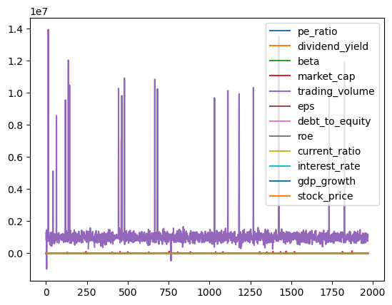

```python
stocks.plot()
```

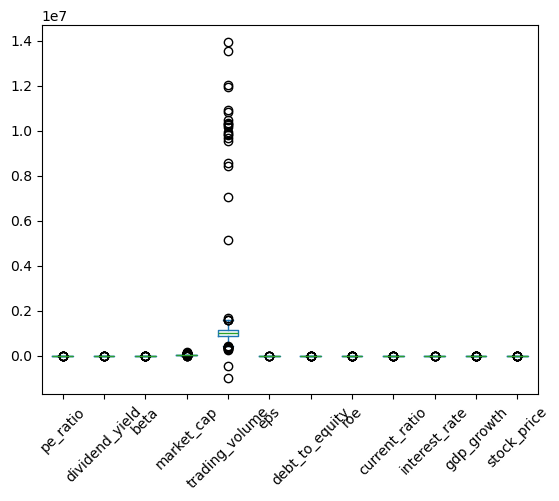

```python
stocks.plot(kind ='box',rot= 45)
```

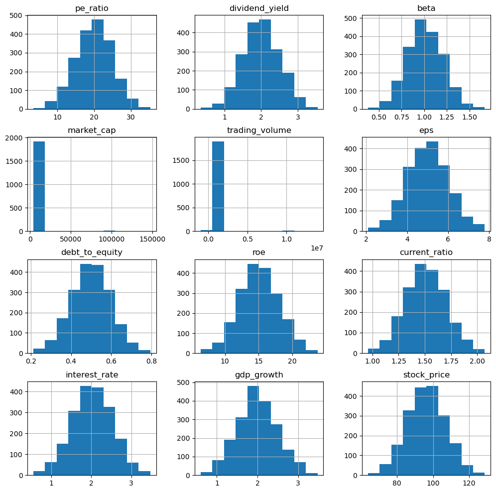

```python
stocks.hist(figsize=(12,12));
```

```python
stocks.head(2)
```

|  | pe_ratio | dividend_yield | beta | market_cap | trading_volume | eps | debt_to_equity | roe | current_ratio | interest_rate | gdp_growth | sector | exchange | rating | stock_price |
| --- | --- | --- | --- | --- | --- | --- | --- | --- | --- | --- | --- | --- | --- | --- | --- |
| 0 | 27.44 | 1.56 | 1.03 | 10120.68 | 1279001.12 | 5.62 | 0.47 | 15.86 | 1.41 | 3.13 | 1.63 | Consumer | AMEX | BB | 90.85 |
| 1 | 21.44 | 2.34 | 0.85 | 9914.20 | 851882.99 | 4.61 | 0.72 | 15.86 | 1.82 | 2.10 | 2.40 | Technology | NYSE | AA | 92.65 |

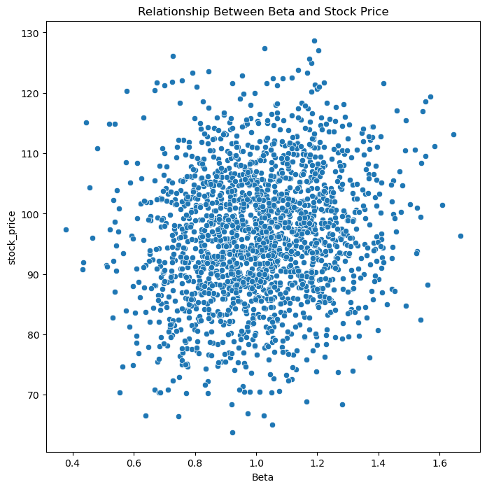

```python
plt.figure(figsize=(8, 8))
sns.scatterplot(data=stocks, x='beta', y='stock_price')
plt.title('Relationship Between Beta and Stock Price')
plt.xlabel('Beta')
plt.ylabel('stock_price')
plt.show()
```

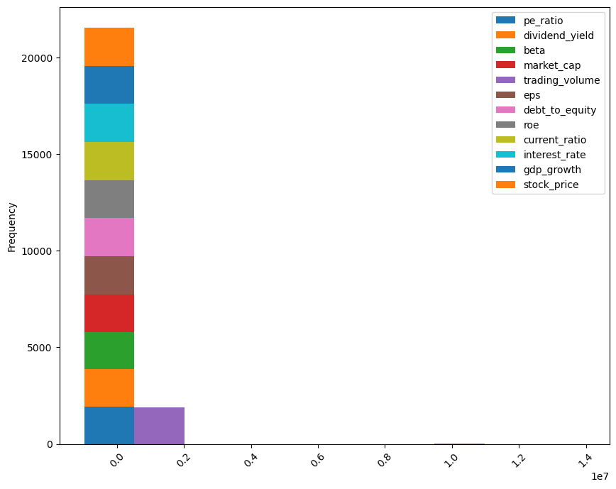

```python
stocks.plot(kind='hist', stacked=True, rot=45, figsize=(10,8));
```

## B. Identify any initial observations about data quality issues, such as missing values or out-liers (inaccurate / inconsistent values).

- Missing values
- Inconsistent/inaccurate values

```python
stocks.isnull().sum() # missing null values.
```

```
pe_ratio          40
dividend_yield    39
beta              40
market_cap        39
trading_volume    40
eps                0
debt_to_equity     0
roe                0
current_ratio      0
interest_rate      0
gdp_growth         0
sector            40
exchange          40
rating             0
stock_price        0
dtype: int64
```

```python
stocks.groupby('sector').size() #sector has duplicate values because of the typos
```

```
sector
Consumer      374
ENERGY         42
Energy        367
Finance       297
Healthcare    420
Technology    357
finance_       34
tech           40
dtype: int64
```

```python
stocks.groupby('exchange').size()# exchange has duplicate values because of the typos
```

```
exchange
AMEX       575
Amex        64
NASDAQ     561
NASDAQ_     61
NYSE       603
nyse        67
dtype: int64
```

```python
stocks.groupby('rating').size() #no null values and data looks clear without typos.
```

```
rating
A      400
AA     397
AAA    394
BB     388
BBB    392
dtype: int64
```

# Task 3: Data Cleaning

## A. Handle missing values. Remove rows containing missing values.

```python
stocks.isnull().sum() # missing null values.
```

```
pe_ratio          40
dividend_yield    39
beta              40
market_cap        39
trading_volume    40
eps                0
debt_to_equity     0
roe                0
current_ratio      0
interest_rate      0
gdp_growth         0
sector            40
exchange          40
rating             0
stock_price        0
dtype: int64
```

```python
stocks = stocks.fillna({'pe_ratio': stocks['pe_ratio'].mean()}) #most prefered.
stocks.isnull().sum()
```

```
pe_ratio           0
dividend_yield    39
beta              40
market_cap        39
trading_volume    40
eps                0
debt_to_equity     0
roe                0
current_ratio      0
interest_rate      0
gdp_growth         0
sector            40
exchange          40
rating             0
stock_price        0
dtype: int64
```

```python
stocks = stocks.fillna({'market_cap': stocks['market_cap'].median()}) #most prefered.
stocks.isnull().sum()
```

```
pe_ratio           0
dividend_yield    39
beta              40
market_cap         0
trading_volume    40
eps                0
debt_to_equity     0
roe                0
current_ratio      0
interest_rate      0
gdp_growth         0
sector            40
exchange          40
rating             0
stock_price        0
dtype: int64
```

```python
stocks = stocks.fillna({'trading_volume': stocks['trading_volume'].max()}) #most prefered.
stocks.isnull().sum()
```

```
pe_ratio           0
dividend_yield    39
beta              40
market_cap         0
trading_volume     0
eps                0
debt_to_equity     0
roe                0
current_ratio      0
interest_rate      0
gdp_growth         0
sector            40
exchange          40
rating             0
stock_price        0
dtype: int64
```

```python
# dropping all the null values for the numerical columns than replacing with mean values or median values as I beloive it is a small percentage and are not so useful values for target variable
#stocks = stocks.dropna(')
stocks.dropna(subset=['dividend_yield','beta'], inplace=True)
stocks.isnull().sum()
```

```
pe_ratio           0
dividend_yield     0
beta               0
market_cap         0
trading_volume     0
eps                0
debt_to_equity     0
roe                0
current_ratio      0
interest_rate      0
gdp_growth         0
sector            39
exchange          40
rating             0
stock_price        0
dtype: int64
```

```python
stocks.head(3)
```

|  | pe_ratio | dividend_yield | beta | market_cap | trading_volume | eps | debt_to_equity | roe | current_ratio | interest_rate | gdp_growth | sector | exchange | rating | stock_price |
| --- | --- | --- | --- | --- | --- | --- | --- | --- | --- | --- | --- | --- | --- | --- | --- |
| 0 | 27.44 | 1.56 | 1.03 | 10120.68 | 1279001.12 | 5.62 | 0.47 | 15.86 | 1.41 | 3.13 | 1.63 | Consumer | AMEX | BB | 90.85 |
| 1 | 21.44 | 2.34 | 0.85 | 9914.20 | 851882.99 | 4.61 | 0.72 | 15.86 | 1.82 | 2.10 | 2.40 | Technology | NYSE | AA | 92.65 |
| 2 | 15.25 | 1.86 | 1.00 | 10842.40 | 850352.01 | 3.19 | 0.33 | 11.97 | 1.80 | 2.84 | 2.84 | Technology | AMEX | BBB | 76.67 |

```python
stocks.tail(3)
```

|  | pe_ratio | dividend_yield | beta | market_cap | trading_volume | eps | debt_to_equity | roe | current_ratio | interest_rate | gdp_growth | sector | exchange | rating | stock_price |
| --- | --- | --- | --- | --- | --- | --- | --- | --- | --- | --- | --- | --- | --- | --- | --- |
| 1968 | 26.33 | 2.61 | 0.74 | 9191.73 | 755990.50 | 3.49 | 0.53 | 18.22 | 1.60 | 1.45 | 0.95 | Energy | NASDAQ | AA | 101.54 |
| 1969 | 14.48 | 1.58 | 1.05 | 11610.91 | 1195169.64 | 6.29 | 0.47 | 12.79 | 1.33 | 2.01 | 2.96 | Technology | NASDAQ | AA | 84.49 |
| 1970 | 14.42 | 2.30 | 0.83 | 7865.98 | 1019367.08 | 4.32 | 0.56 | 14.62 | 1.51 | 2.28 | 2.09 | NaN | NASDAQ_ | BB | 85.29 |

## B. Identify and handle inaccurate values/outliers (e.g., negative values) in numerical columns.

```python
# Identifying negative values.
#(stocks[numeric_only=True] < 0).values.any()
#(stocks['pe_ratio','dividend_yield','beta','market_cap','trading_volume','eps','debt-to_equity','roe','current_ratio','interest_rate','gdp_growth','stock_price'] < 0).any()
#df.columns[(df < 0).any()]
#Index(['pe_ratio','dividend_yield','beta','market_cap','trading_volume','eps','debt-to_equity','roe','current_ratio','interest_rate','gdp_growth','stock_price'], dtype='float')

#c = np.where(df < 0)
#stocks.columns[c]

NC = [c for c in stocks.columns if stocks[c].dtype.name != 'object']
stocks[stocks[NC] < 0].count() #only trading_volume has negative values.
```

```
pe_ratio          0
dividend_yield    0
beta              0
market_cap        0
trading_volume    2
eps               0
debt_to_equity    0
roe               0
current_ratio     0
interest_rate     0
gdp_growth        0
sector            0
exchange          0
rating            0
stock_price       0
dtype: int64
```

```python
# converting negative values to 0
stocks.loc[stocks['trading_volume']<0,'trading_volume'] = 0
stocks[(stocks['trading_volume'] == 0)].head()
```

|  | pe_ratio | dividend_yield | beta | market_cap | trading_volume | eps | debt_to_equity | roe | current_ratio | interest_rate | gdp_growth | sector | exchange | rating | stock_price |
| --- | --- | --- | --- | --- | --- | --- | --- | --- | --- | --- | --- | --- | --- | --- | --- |
| 4 | 13.47 | 2.33 | 1.07 | 9164.46 | 0.00 | 2.68 | 0.55 | 15.77 | 1.40 | 2.45 | 1.68 | Consumer | NASDAQ | AAA | 82.33 |
| 765 | 10.18 | 2.78 | 1.16 | 11284.31 | 0.00 | 4.44 | 0.41 | 13.88 | 1.41 | 1.14 | 2.50 | Finance | NYSE | AAA | 94.21 |

```python
stocks[stocks[NC] < 0].count() # no negative values.
```

```
pe_ratio          0
dividend_yield    0
beta              0
market_cap        0
trading_volume    0
eps               0
debt_to_equity    0
roe               0
current_ratio     0
interest_rate     0
gdp_growth        0
sector            0
exchange          0
rating            0
stock_price       0
dtype: int64
```

## C. Correct any inconsistencies in categorical columns, such as varying capitalization or ty-pos.

Sector data cleaning

```python
stocks.groupby('sector').size()
```

```
sector
Consumer      364
ENERGY         39
Energy        351
Finance       285
Healthcare    398
Technology    350
finance_       30
tech           39
dtype: int64
```

```python
stocks = stocks.replace({'sector': 'tech'}, {'sector': 'Technology'})
stocks.head(2)
```

|  | pe_ratio | dividend_yield | beta | market_cap | trading_volume | eps | debt_to_equity | roe | current_ratio | interest_rate | gdp_growth | sector | exchange | rating | stock_price |
| --- | --- | --- | --- | --- | --- | --- | --- | --- | --- | --- | --- | --- | --- | --- | --- |
| 0 | 27.44 | 1.56 | 1.03 | 10120.68 | 1279001.12 | 5.62 | 0.47 | 15.86 | 1.41 | 3.13 | 1.63 | Consumer | AMEX | BB | 90.85 |
| 1 | 21.44 | 2.34 | 0.85 | 9914.20 | 851882.99 | 4.61 | 0.72 | 15.86 | 1.82 | 2.10 | 2.40 | Technology | NYSE | AA | 92.65 |

```python
stocks = stocks.replace({'sector': 'ENERGY'}, {'sector': 'Energy'})
stocks.head(2)
```

|  | pe_ratio | dividend_yield | beta | market_cap | trading_volume | eps | debt_to_equity | roe | current_ratio | interest_rate | gdp_growth | sector | exchange | rating | stock_price |
| --- | --- | --- | --- | --- | --- | --- | --- | --- | --- | --- | --- | --- | --- | --- | --- |
| 0 | 27.44 | 1.56 | 1.03 | 10120.68 | 1279001.12 | 5.62 | 0.47 | 15.86 | 1.41 | 3.13 | 1.63 | Consumer | AMEX | BB | 90.85 |
| 1 | 21.44 | 2.34 | 0.85 | 9914.20 | 851882.99 | 4.61 | 0.72 | 15.86 | 1.82 | 2.10 | 2.40 | Technology | NYSE | AA | 92.65 |

```python
stocks = stocks.replace({'sector': 'finance_'}, {'sector': 'Finance'})
stocks.head(2)
```

|  | pe_ratio | dividend_yield | beta | market_cap | trading_volume | eps | debt_to_equity | roe | current_ratio | interest_rate | gdp_growth | sector | exchange | rating | stock_price |
| --- | --- | --- | --- | --- | --- | --- | --- | --- | --- | --- | --- | --- | --- | --- | --- |
| 0 | 27.44 | 1.56 | 1.03 | 10120.68 | 1279001.12 | 5.62 | 0.47 | 15.86 | 1.41 | 3.13 | 1.63 | Consumer | AMEX | BB | 90.85 |
| 1 | 21.44 | 2.34 | 0.85 | 9914.20 | 851882.99 | 4.61 | 0.72 | 15.86 | 1.82 | 2.10 | 2.40 | Technology | NYSE | AA | 92.65 |

```python
stocks['sector'].unique() # we still have null values.
```

```
array(['Consumer', 'Technology', 'Finance', 'Healthcare', 'Energy', nan],
      dtype=object)
```

```python
#replacing null values with most common sector that is healthcare.
stocks = stocks.fillna({'sector': stocks['sector'].mode()[0]})
stocks.isnull().sum()
```

```
pe_ratio           0
dividend_yield     0
beta               0
market_cap         0
trading_volume     0
eps                0
debt_to_equity     0
roe                0
current_ratio      0
interest_rate      0
gdp_growth         0
sector             0
exchange          40
rating             0
stock_price        0
dtype: int64
```

```python
stocks.groupby('sector').size() # we  have no  null values and all the null values are changed to healthcare.
```

```
sector
Consumer      364
Energy        390
Finance       315
Healthcare    437
Technology    389
dtype: int64
```

Exchange data issues

```python
stocks['exchange'].unique() # we have null values and wrong spellings
```

```
array(['AMEX', 'NYSE', 'NASDAQ', 'Amex', 'nyse', 'NASDAQ_', nan],
      dtype=object)
```

```python
stocks.groupby('exchange').size()
```

```
exchange
AMEX       557
Amex        61
NASDAQ     543
NASDAQ_     60
NYSE       573
nyse        61
dtype: int64
```

```python
stocks = stocks.replace({'exchange': 'Amex'}, {'exchange': 'AMEX'})
stocks.head(2)
```

|  | pe_ratio | dividend_yield | beta | market_cap | trading_volume | eps | debt_to_equity | roe | current_ratio | interest_rate | gdp_growth | sector | exchange | rating | stock_price |
| --- | --- | --- | --- | --- | --- | --- | --- | --- | --- | --- | --- | --- | --- | --- | --- |
| 0 | 27.44 | 1.56 | 1.03 | 10120.68 | 1279001.12 | 5.62 | 0.47 | 15.86 | 1.41 | 3.13 | 1.63 | Consumer | AMEX | BB | 90.85 |
| 1 | 21.44 | 2.34 | 0.85 | 9914.20 | 851882.99 | 4.61 | 0.72 | 15.86 | 1.82 | 2.10 | 2.40 | Technology | NYSE | AA | 92.65 |

```python
stocks = stocks.replace({'exchange': 'NASDAQ_'}, {'exchange': 'NASDAQ'})
stocks.head(2)
```

|  | pe_ratio | dividend_yield | beta | market_cap | trading_volume | eps | debt_to_equity | roe | current_ratio | interest_rate | gdp_growth | sector | exchange | rating | stock_price |
| --- | --- | --- | --- | --- | --- | --- | --- | --- | --- | --- | --- | --- | --- | --- | --- |
| 0 | 27.44 | 1.56 | 1.03 | 10120.68 | 1279001.12 | 5.62 | 0.47 | 15.86 | 1.41 | 3.13 | 1.63 | Consumer | AMEX | BB | 90.85 |
| 1 | 21.44 | 2.34 | 0.85 | 9914.20 | 851882.99 | 4.61 | 0.72 | 15.86 | 1.82 | 2.10 | 2.40 | Technology | NYSE | AA | 92.65 |

```python
stocks = stocks.replace({'exchange': 'nyse'}, {'exchange': 'NYSE'})
stocks.head(2)
```

|  | pe_ratio | dividend_yield | beta | market_cap | trading_volume | eps | debt_to_equity | roe | current_ratio | interest_rate | gdp_growth | sector | exchange | rating | stock_price |
| --- | --- | --- | --- | --- | --- | --- | --- | --- | --- | --- | --- | --- | --- | --- | --- |
| 0 | 27.44 | 1.56 | 1.03 | 10120.68 | 1279001.12 | 5.62 | 0.47 | 15.86 | 1.41 | 3.13 | 1.63 | Consumer | AMEX | BB | 90.85 |
| 1 | 21.44 | 2.34 | 0.85 | 9914.20 | 851882.99 | 4.61 | 0.72 | 15.86 | 1.82 | 2.10 | 2.40 | Technology | NYSE | AA | 92.65 |

```python
stocks.groupby('exchange').size()
```

```
exchange
AMEX      618
NASDAQ    603
NYSE      634
dtype: int64
```

```python
#replacing null values with most common sector that is Nyse.
stocks = stocks.fillna({'exchange': stocks['exchange'].mode()[0]})
stocks.isnull().sum()
```

```
pe_ratio          0
dividend_yield    0
beta              0
market_cap        0
trading_volume    0
eps               0
debt_to_equity    0
roe               0
current_ratio     0
interest_rate     0
gdp_growth        0
sector            0
exchange          0
rating            0
stock_price       0
dtype: int64
```

```python
stocks.groupby('exchange').size() #null values are removed and nyse has increased.
```

```
exchange
AMEX      618
NASDAQ    603
NYSE      674
dtype: int64
```

Rating data cleaning

```python
stocks.groupby('rating').size() #no null values and data looks clear.
```

```
rating
A      388
AA     384
AAA    372
BB     375
BBB    376
dtype: int64
```

```python
stocks.head(2)
```

|  | pe_ratio | dividend_yield | beta | market_cap | trading_volume | eps | debt_to_equity | roe | current_ratio | interest_rate | gdp_growth | sector | exchange | rating | stock_price |
| --- | --- | --- | --- | --- | --- | --- | --- | --- | --- | --- | --- | --- | --- | --- | --- |
| 0 | 27.44 | 1.56 | 1.03 | 10120.68 | 1279001.12 | 5.62 | 0.47 | 15.86 | 1.41 | 3.13 | 1.63 | Consumer | AMEX | BB | 90.85 |
| 1 | 21.44 | 2.34 | 0.85 | 9914.20 | 851882.99 | 4.61 | 0.72 | 15.86 | 1.82 | 2.10 | 2.40 | Technology | NYSE | AA | 92.65 |

# Task 4: Correlation Analysis

**Note**: We don't want to make any further changes to `df`. To conduct correlation analysis, it's recommended to create a copy of the original dataframe (`df_corr`) and convert categorical columns to dummy variables.

```python
df_corr = stocks.copy()
```

```python
df_corr = pd.get_dummies(df_corr, columns=['sector', 'exchange', 'rating'])
```

```python
df_corr.head()
```

|  | pe_ratio | dividend_yield | beta | market_cap | trading_volume | eps | debt_to_equity | roe | current_ratio | interest_rate | ... | sector_Healthcare | sector_Technology | exchange_AMEX | exchange_NASDAQ | exchange_NYSE | rating_A | rating_AA | rating_AAA | rating_BB | rating_BBB |
| --- | --- | --- | --- | --- | --- | --- | --- | --- | --- | --- | --- | --- | --- | --- | --- | --- | --- | --- | --- | --- | --- |
| 0 | 27.44 | 1.56 | 1.03 | 10120.68 | 1279001.12 | 5.62 | 0.47 | 15.86 | 1.41 | 3.13 | ... | False | False | True | False | False | False | False | False | True | False |
| 1 | 21.44 | 2.34 | 0.85 | 9914.20 | 851882.99 | 4.61 | 0.72 | 15.86 | 1.82 | 2.10 | ... | False | True | False | False | True | False | True | False | False | False |
| 2 | 15.25 | 1.86 | 1.00 | 10842.40 | 850352.01 | 3.19 | 0.33 | 11.97 | 1.80 | 2.84 | ... | False | True | True | False | False | False | False | False | False | True |
| 3 | 24.48 | 1.56 | 1.00 | 8654.20 | 966156.92 | 4.20 | 0.69 | 17.40 | 1.17 | 2.26 | ... | False | False | False | True | False | False | False | False | False | True |
| 4 | 13.47 | 2.33 | 1.07 | 9164.46 | 0.00 | 2.68 | 0.55 | 15.77 | 1.40 | 2.45 | ... | False | False | False | True | False | False | False | True | False | False |

5 rows × 25 columns

## A. Calculate the correlation matrix between the features and the target variable.

```python
df_corr.info()
```

```
<class 'pandas.core.frame.DataFrame'>
Index: 1895 entries, 0 to 1970
Data columns (total 25 columns):
 #   Column             Non-Null Count  Dtype
---  ------             --------------  -----
 0   pe_ratio           1895 non-null   float64
 1   dividend_yield     1895 non-null   float64
 2   beta               1895 non-null   float64
 3   market_cap         1895 non-null   float64
 4   trading_volume     1895 non-null   float64
 5   eps                1895 non-null   float64
 6   debt_to_equity     1895 non-null   float64
 7   roe                1895 non-null   float64
 8   current_ratio      1895 non-null   float64
 9   interest_rate      1895 non-null   float64
```

[output cut: 17 more lines]

```python
df_corr.corr(numeric_only=True)['stock_price'].sort_values()#the co relation between target variable and features.
```

```
debt_to_equity      -0.09
interest_rate       -0.07
exchange_NASDAQ     -0.05
rating_BB           -0.04
sector_Consumer     -0.04
sector_Healthcare   -0.03
gdp_growth          -0.03
rating_AAA          -0.02
trading_volume      -0.02
rating_AA           -0.02
sector_Technology   -0.00
market_cap           0.01
rating_A             0.02
exchange_AMEX        0.03
exchange_NYSE        0.03
sector_Finance       0.03
current_ratio        0.03
sector_Energy        0.05
rating_BBB           0.06
roe                  0.13
beta                 0.14
pe_ratio             0.14
eps                  0.20
dividend_yield       0.23
stock_price          1.00
Name: stock_price, dtype: float64
```

## B. Create visualizations like heatmaps to better understand these correlations.

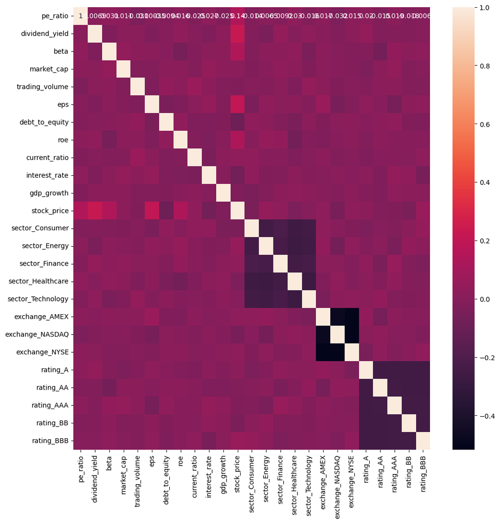

```python
# correlation heatmap
plt.figure(figsize=(12,12))
sns.heatmap(df_corr.corr(numeric_only=True), annot=True);
```

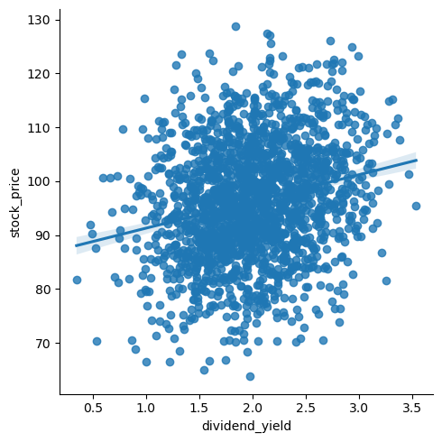

```python
sns.lmplot(x='dividend_yield', y='stock_price', data=stocks);
```

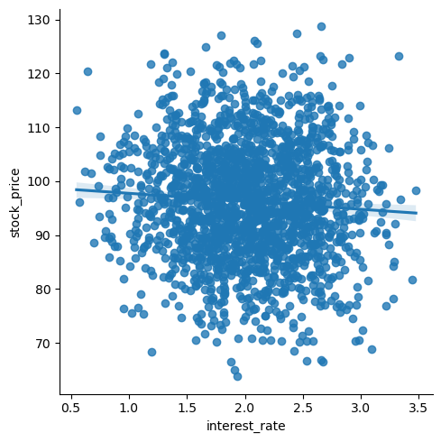

```python
# choosing  another variable for lmplot with stock_price
sns.lmplot(x='interest_rate', y='stock_price', data=df_corr);
```

## C. Discuss your findings and identify which features are most strongly correlated with the stock price.

beta and pe_ratio are related target variable y by 0.14,eps by 0.20 and dividend_yield by 0.23 these are the 4 features which are strongly co-related to stock price.

# Task 5: Data Splitting (and Data Preprocessing, if necessary)

To perform split validation and prepare data for model building, you can use the `df` tool for data processing.

## A. Split the dataset into training and validation sets. Ensure that both sets are representa-tive of the overall dataset.

```python
# Set X features and y variable

y = df_corr['stock_price']
X = df_corr.drop(['stock_price'], axis =1)  #a simple way to assign X variables (preferred) #better approcah
```

```python
y.head(2)
```

```
0   90.85
1   92.65
Name: stock_price, dtype: float64
```

```python
X.head(2)
```

|  | pe_ratio | dividend_yield | beta | market_cap | trading_volume | eps | debt_to_equity | roe | current_ratio | interest_rate | ... | sector_Healthcare | sector_Technology | exchange_AMEX | exchange_NASDAQ | exchange_NYSE | rating_A | rating_AA | rating_AAA | rating_BB | rating_BBB |
| --- | --- | --- | --- | --- | --- | --- | --- | --- | --- | --- | --- | --- | --- | --- | --- | --- | --- | --- | --- | --- | --- |
| 0 | 27.44 | 1.56 | 1.03 | 10120.68 | 1279001.12 | 5.62 | 0.47 | 15.86 | 1.41 | 3.13 | ... | False | False | True | False | False | False | False | False | True | False |
| 1 | 21.44 | 2.34 | 0.85 | 9914.20 | 851882.99 | 4.61 | 0.72 | 15.86 | 1.82 | 2.10 | ... | False | True | False | False | True | False | True | False | False | False |

2 rows × 24 columns

```python
# Splitting the data into training and test sets (80% training, 20% testing)
X_train, X_test, y_train, y_test = train_test_split(X, y, test_size=0.2, random_state=0)

print(X_train.shape, y_train.shape, X_test.shape, y_test.shape)
```

```
(1516, 24) (1516,) (379, 24) (379,)
```

```python
# let's double check

print(len(df_corr))
print(len(df_corr) * 0.8)        # 80% of the original data
print(len(df_corr) * 0.2)        # 20% of the original data
```

```
1895
1516.0
379.0
```

```python
y_train.head(2)
```

```
399   90.88
33    95.64
Name: stock_price, dtype: float64
```

```python
y_test.head(2)
```

```
302   109.52
340    96.66
Name: stock_price, dtype: float64
```

```python
X_train.head(2)
```

|  | pe_ratio | dividend_yield | beta | market_cap | trading_volume | eps | debt_to_equity | roe | current_ratio | interest_rate | ... | sector_Healthcare | sector_Technology | exchange_AMEX | exchange_NASDAQ | exchange_NYSE | rating_A | rating_AA | rating_AAA | rating_BB | rating_BBB |
| --- | --- | --- | --- | --- | --- | --- | --- | --- | --- | --- | --- | --- | --- | --- | --- | --- | --- | --- | --- | --- | --- |
| 399 | 21.89 | 1.69 | 1.03 | 10138.03 | 1112099.80 | 5.43 | 0.37 | 14.54 | 1.21 | 2.22 | ... | False | True | True | False | False | False | False | False | False | True |
| 33 | 16.97 | 2.42 | 0.73 | 9879.04 | 785858.49 | 5.62 | 0.41 | 17.09 | 1.51 | 1.88 | ... | False | True | False | False | True | True | False | False | False | False |

2 rows × 24 columns

```python
X_test.head(2)
```

|  | pe_ratio | dividend_yield | beta | market_cap | trading_volume | eps | debt_to_equity | roe | current_ratio | interest_rate | ... | sector_Healthcare | sector_Technology | exchange_AMEX | exchange_NASDAQ | exchange_NYSE | rating_A | rating_AA | rating_AAA | rating_BB | rating_BBB |
| --- | --- | --- | --- | --- | --- | --- | --- | --- | --- | --- | --- | --- | --- | --- | --- | --- | --- | --- | --- | --- | --- |
| 302 | 10.43 | 2.04 | 0.79 | 10974.51 | 669442.61 | 5.80 | 0.46 | 12.58 | 1.47 | 2.37 | ... | False | False | True | False | False | True | False | False | False | False |
| 340 | 11.36 | 1.54 | 1.41 | 8910.95 | 1207037.60 | 4.08 | 0.54 | 10.41 | 1.59 | 2.54 | ... | False | False | False | True | False | False | False | False | True | False |

2 rows × 24 columns

## B. Perform data preprocessing (e.g., encoding, standardizing) for model building if necessary. Explain why you did or did not choose to do data preprocessing.

```python
num_cols = df_corr.select_dtypes(include=[np.number]).drop(columns=['stock_price']).columns
cat_cols = df_corr.select_dtypes(include=[bool]).columns
print(num_cols, cat_cols)
```

```
Index(['pe_ratio', 'dividend_yield', 'beta', 'market_cap', 'trading_volume',
       'eps', 'debt_to_equity', 'roe', 'current_ratio', 'interest_rate',
       'gdp_growth'],
      dtype='object') Index(['sector_Consumer', 'sector_Energy', 'sector_Finance',
       'sector_Healthcare', 'sector_Technology', 'exchange_AMEX',
       'exchange_NASDAQ', 'exchange_NYSE', 'rating_A', 'rating_AA',
       'rating_AAA', 'rating_BB', 'rating_BBB'],
      dtype='object')
```

```python
df_corr.info()
```

```
<class 'pandas.core.frame.DataFrame'>
Index: 1895 entries, 0 to 1970
Data columns (total 25 columns):
 #   Column             Non-Null Count  Dtype
---  ------             --------------  -----
 0   pe_ratio           1895 non-null   float64
 1   dividend_yield     1895 non-null   float64
 2   beta               1895 non-null   float64
 3   market_cap         1895 non-null   float64
 4   trading_volume     1895 non-null   float64
 5   eps                1895 non-null   float64
 6   debt_to_equity     1895 non-null   float64
 7   roe                1895 non-null   float64
 8   current_ratio      1895 non-null   float64
 9   interest_rate      1895 non-null   float64
```

[output cut: 17 more lines]

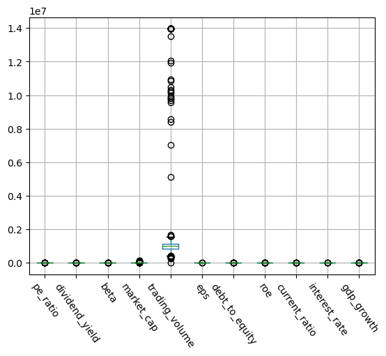

```python
X_train[num_cols].boxplot(rot = -55)
```

```python
X_normalized = normalize(df_corr)

X_normalized
```

```
array([[2.14553426e-05, 1.22149039e-06, 8.06396311e-07, ...,
        0.00000000e+00, 7.81835663e-07, 0.00000000e+00],
       [2.51636078e-05, 2.75154854e-06, 9.97303503e-07, ...,
        0.00000000e+00, 0.00000000e+00, 0.00000000e+00],
       [1.79265289e-05, 2.18873366e-06, 1.17966867e-06, ...,
        0.00000000e+00, 0.00000000e+00, 1.17588800e-06],
       ...,
       [3.48260991e-05, 3.44612965e-06, 9.77711589e-07, ...,
        0.00000000e+00, 0.00000000e+00, 0.00000000e+00],
       [1.21130159e-05, 1.32357581e-06, 8.77118322e-07, ...,
        0.00000000e+00, 0.00000000e+00, 0.00000000e+00],
       [1.41454347e-05, 2.25913319e-06, 8.12823235e-07, ...,
        0.00000000e+00, 9.80971665e-07, 0.00000000e+00]])
```

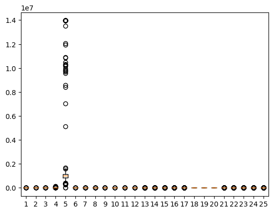

```python
plt.boxplot(df_corr);
```

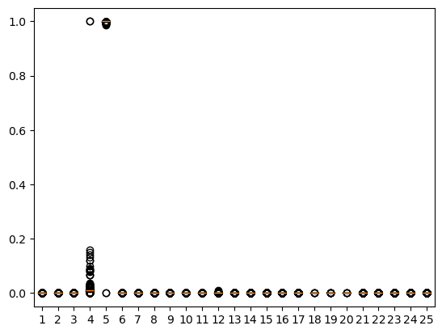

```python
# columns are normalized ... in same scale
plt.boxplot(X_normalized);
```

```python
X.head()
```

|  | pe_ratio | dividend_yield | beta | market_cap | trading_volume | eps | debt_to_equity | roe | current_ratio | interest_rate | ... | sector_Healthcare | sector_Technology | exchange_AMEX | exchange_NASDAQ | exchange_NYSE | rating_A | rating_AA | rating_AAA | rating_BB | rating_BBB |
| --- | --- | --- | --- | --- | --- | --- | --- | --- | --- | --- | --- | --- | --- | --- | --- | --- | --- | --- | --- | --- | --- |
| 0 | 27.44 | 1.56 | 1.03 | 10120.68 | 1279001.12 | 5.62 | 0.47 | 15.86 | 1.41 | 3.13 | ... | False | False | True | False | False | False | False | False | True | False |
| 1 | 21.44 | 2.34 | 0.85 | 9914.20 | 851882.99 | 4.61 | 0.72 | 15.86 | 1.82 | 2.10 | ... | False | True | False | False | True | False | True | False | False | False |
| 2 | 15.25 | 1.86 | 1.00 | 10842.40 | 850352.01 | 3.19 | 0.33 | 11.97 | 1.80 | 2.84 | ... | False | True | True | False | False | False | False | False | False | True |
| 3 | 24.48 | 1.56 | 1.00 | 8654.20 | 966156.92 | 4.20 | 0.69 | 17.40 | 1.17 | 2.26 | ... | False | False | False | True | False | False | False | False | False | True |
| 4 | 13.47 | 2.33 | 1.07 | 9164.46 | 0.00 | 2.68 | 0.55 | 15.77 | 1.40 | 2.45 | ... | False | False | False | True | False | False | False | True | False | False |

5 rows × 24 columns

```python
from sklearn.preprocessing import Normalizer

y = df_corr['stock_price']
X = df_corr.drop(['stock_price'], axis =1)   # remove salary

# model building
scaler = Normalizer().fit(X)
normalizedX = scaler.transform(X)
normalizedX
```

```
array([[2.14553427e-05, 1.22149040e-06, 8.06396314e-07, ...,
        0.00000000e+00, 7.81835665e-07, 0.00000000e+00],
       [2.51636079e-05, 2.75154855e-06, 9.97303508e-07, ...,
        0.00000000e+00, 0.00000000e+00, 0.00000000e+00],
       [1.79265290e-05, 2.18873367e-06, 1.17966867e-06, ...,
        0.00000000e+00, 0.00000000e+00, 1.17588800e-06],
       ...,
       [3.48260994e-05, 3.44612968e-06, 9.77711598e-07, ...,
        0.00000000e+00, 0.00000000e+00, 0.00000000e+00],
       [1.21130159e-05, 1.32357581e-06, 8.77118325e-07, ...,
        0.00000000e+00, 0.00000000e+00, 0.00000000e+00],
       [1.41454348e-05, 2.25913319e-06, 8.12823238e-07, ...,
        0.00000000e+00, 9.80971669e-07, 0.00000000e+00]])
```

# Task 6: Model Building

## A. Train multiple regression models

• Linear Regression and Random Forest

```python
df_corr.info()
```

```
<class 'pandas.core.frame.DataFrame'>
Index: 1895 entries, 0 to 1970
Data columns (total 25 columns):
 #   Column             Non-Null Count  Dtype
---  ------             --------------  -----
 0   pe_ratio           1895 non-null   float64
 1   dividend_yield     1895 non-null   float64
 2   beta               1895 non-null   float64
 3   market_cap         1895 non-null   float64
 4   trading_volume     1895 non-null   float64
 5   eps                1895 non-null   float64
 6   debt_to_equity     1895 non-null   float64
 7   roe                1895 non-null   float64
 8   current_ratio      1895 non-null   float64
 9   interest_rate      1895 non-null   float64
```

[output cut: 17 more lines]

```python
model = LinearRegression()
model.fit(X_train,y_train)
```

```
LinearRegression()
```

```python
#linear regression model 1

model1 = lm.LinearRegression()
model1.fit(X_train, y_train)
model1_y = model1.predict(X_test)
```

```python
# this is regression so it has coefficients and y-intercept

print('Coefficients: ', model1.coef_)
print("y-intercept ", model1.intercept_)
```

```
Coefficients:  [ 3.20395783e-01  5.00295655e+00  7.50354484e+00  1.38827543e-05
 -1.14983502e-07  2.12354741e+00 -9.57496910e+00  5.10877671e-01
  1.48937436e+00 -1.80077897e+00 -2.70949587e-01 -6.61115049e-01
  7.02127453e-01  5.14039455e-01 -6.99500299e-01  1.44448440e-01
  1.59189961e-02 -4.86585527e-01  4.70666531e-01  9.14880122e-02
 -2.76839803e-01 -2.29888228e-01 -6.05157922e-01  1.02039794e+00]
y-intercept  60.73471751660914
```

```python
pd.DataFrame(list(zip(X.columns, np.transpose(model1.coef_)))).round(2)
```

|  | 0 | 1 |
| --- | --- | --- |
| 0 | pe_ratio | 0.32 |
| 1 | dividend_yield | 5.00 |
| 2 | beta | 7.50 |
| 3 | market_cap | 0.00 |
| 4 | trading_volume | -0.00 |
| 5 | eps | 2.12 |
| 6 | debt_to_equity | -9.57 |
| 7 | roe | 0.51 |
| 8 | current_ratio | 1.49 |
| 9 | interest_rate | -1.80 |
| 10 | gdp_growth | -0.27 |
| 11 | sector_Consumer | -0.66 |
| 12 | sector_Energy | 0.70 |
| 13 | sector_Finance | 0.51 |
| 14 | sector_Healthcare | -0.70 |
| 15 | sector_Technology | 0.14 |
| 16 | exchange_AMEX | 0.02 |
| 17 | exchange_NASDAQ | -0.49 |
| 18 | exchange_NYSE | 0.47 |
| 19 | rating_A | 0.09 |
| 20 | rating_AA | -0.28 |
| 21 | rating_AAA | -0.23 |
| 22 | rating_BB | -0.61 |
| 23 | rating_BBB | 1.02 |

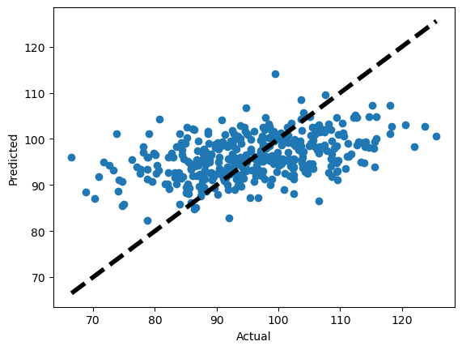

```python
plt.subplots()
plt.scatter(y_test, model1_y)       # showing actual y as X-axis and predicted y as Y-axis
plt.plot([y_test.min(), y_test.max()], [y_test.min(), y_test.max()], 'k--', lw=4)   #dotted line represents perfect prediction (actual = predicted)
plt.xlabel('Actual')
plt.ylabel('Predicted')
plt.show()
```

```python
#model 1 evaluation
print("mean square error: ", mean_squared_error(y_test, model1_y))
print("variance or r-squared: ", explained_variance_score(y_test, model1_y))
```

```
mean square error:  91.85851109979119
variance or r-squared:  0.18416942523923763
```

```python
#linear regression model 2
# Choosing two variables as X (dividend_yield, beta)  and develop a multiple linear regression model (model2).
y = df_corr['stock_price']
X = df_corr[['dividend_yield','beta']]

print(X.shape,y.shape)
```

[output not shown]

```python
X_train, X_test, y_train, y_test = train_test_split(X, y, test_size=0.3, random_state=0)

print(X_train.shape, y_train.shape, X_test.shape, y_test.shape)
```

[output not shown]

```python
# building random forest regression model 2

model2 = lm.LinearRegression()
model2.fit(X_train, y_train)
model2_y = model2.predict(X_test)
```

```python
pd.DataFrame(list(zip(X.columns, np.transpose(model2.coef_)))).round(2)
```

|  | 0 | 1 |
| --- | --- | --- |
| 0 | dividend_yield | 5.13 |
| 1 | beta | 8.04 |

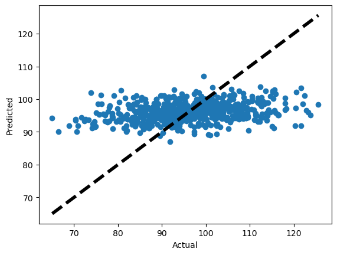

```python
plt.subplots()
plt.scatter(y_test, model2_y)       # showing actual y as X-axis and predicted y as Y-axis
plt.plot([y_test.min(), y_test.max()], [y_test.min(), y_test.max()], 'k--', lw=4)   #dotted line represents perfect prediction (actual = predicted)
plt.xlabel('Actual')
plt.ylabel('Predicted')
plt.show()
```

```python
#model 2 evaluation
print("mean square error: ", mean_squared_error(y_test, model2_y))
print("variance or r-squared: ", explained_variance_score(y_test, model2_y))
```

```
mean square error:  110.43838501225679
variance or r-squared:  0.07149004556392757
```

```python
# this is regression so it has coefficients and y-intercept

print('Coefficients: ', model2.coef_)
print("y-intercept ", model2.intercept_)
```

```
Coefficients:  [5.12895406 8.03742314]
y-intercept  77.87596904714479
```

## B. Train regression models using advanced methods

- One feature selection technique
- One regularized algorithm (Lasso)

```python
y = df_corr['stock_price']
X = df_corr.drop(['stock_price'], axis =1)
```

```python
# split validation (80% training & 20% testing data)

X_train, X_test, y_train, y_test = train_test_split(X, y, test_size=0.3, random_state=0)

print(X_train.shape, y_train.shape, X_test.shape, y_test.shape)
```

```
(1326, 24) (1326,) (569, 24) (569,)
```

```python
#Fit the model
           #higher alpha (penality parameter), fewer predictors

#step 1 initialize the algorithm of choice --> Lasso
model3 = lm.Lasso(alpha=0.1) #Reduces X variables.

#step 2 : Use fit function--> imp step
model3.fit(X_train,y_train)
```

```
Lasso(alpha=0.1)
```

```python
print('Coefficients: ', model3.coef_)
print("y-intercept ", model3.intercept_)
```

```
Coefficients:  [ 2.87055217e-01  4.67509670e+00  5.55912375e+00  9.16839657e-06
 -8.86896741e-08  1.94879246e+00 -0.00000000e+00  4.75862998e-01
  0.00000000e+00 -1.55827997e+00 -0.00000000e+00 -0.00000000e+00
  2.27823346e-01  0.00000000e+00 -2.74721275e-01  0.00000000e+00
 -0.00000000e+00 -2.68519446e-01  2.19976039e-01  0.00000000e+00
 -0.00000000e+00 -0.00000000e+00 -0.00000000e+00  8.46086879e-01]
y-intercept  61.633420059615716
```

```python
pd.DataFrame(list(zip(X.columns, np.transpose(model3.coef_)))).round(2)
```

|  | 0 | 1 |
| --- | --- | --- |
| 0 | pe_ratio | 0.29 |
| 1 | dividend_yield | 4.68 |
| 2 | beta | 5.56 |
| 3 | market_cap | 0.00 |
| 4 | trading_volume | -0.00 |
| 5 | eps | 1.95 |
| 6 | debt_to_equity | -0.00 |
| 7 | roe | 0.48 |
| 8 | current_ratio | 0.00 |
| 9 | interest_rate | -1.56 |
| 10 | gdp_growth | -0.00 |
| 11 | sector_Consumer | -0.00 |
| 12 | sector_Energy | 0.23 |
| 13 | sector_Finance | 0.00 |
| 14 | sector_Healthcare | -0.27 |
| 15 | sector_Technology | 0.00 |
| 16 | exchange_AMEX | -0.00 |
| 17 | exchange_NASDAQ | -0.27 |
| 18 | exchange_NYSE | 0.22 |
| 19 | rating_A | 0.00 |
| 20 | rating_AA | -0.00 |
| 21 | rating_AAA | -0.00 |
| 22 | rating_BB | -0.00 |
| 23 | rating_BBB | 0.85 |

The regression model has become a lot simpler than the full model with all X variables. Several X variables were removed from the model, including **market_cap, trading_volume, current_ratio, debt_to_equity, gdp_growth,sector_Finance,sector_Technology,exchange_AMEX, rating_A,rating_AA,rating_AAA,and rating_BB**. These removed variables have their **coefficients close to 0**.

```python
# Predict on the training and testing data
y_train_pred = model3.predict(X_train)
y_test_pred = model3.predict(X_test)

print("mean square error: ", mean_squared_error(y_test, y_test_pred))
print("variance or r-squared: ", explained_variance_score(y_test, y_test_pred))
```

```
mean square error:  100.05687369557192
variance or r-squared:  0.15878526451161368
```

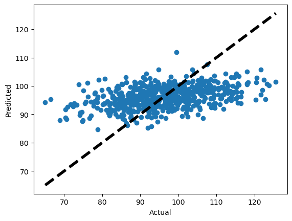

```python
plt.subplots()
plt.scatter(y_test, y_test_pred)       # showing actual y as X-axis and predicted y as Y-axis
plt.plot([y_test.min(), y_test.max()], [y_test.min(), y_test.max()], 'k--', lw=4)   #dotted line represents perfect prediction (actual = predicted)
plt.xlabel('Actual')
plt.ylabel('Predicted')
plt.show()
```

```python
from sklearn.ensemble import RandomForestRegressor #decision tree base regression. Diff from previous algorithm.
from sklearn.datasets import make_regression
```

```python
#assigning columns to X and Y variables
y = df_corr['stock_price']
X = df_corr.drop(['stock_price'], axis =1)

# split validation (80% training & 20% testing data)
X_train, X_test, y_train, y_test = train_test_split(X, y, test_size=0.2, random_state=0)

# model building
regr = RandomForestRegressor(random_state=0)
regr.fit(X_train, y_train)
regr_predicted = regr.predict(X_test)

print("mean square error: ", mean_squared_error(y_test, regr_predicted))
print("variance or r-squared: ", explained_variance_score(y_test, regr_predicted))
```

```
mean square error:  100.32183527927742
variance or r-squared:  0.10900705128956856
```

f_Regression

```python
# Model 4
#selec only 2 X variables
X_new = SelectKBest(f_regression, k=2).fit_transform(X, y)
X_new
```

```
array([[1.5623365 , 5.62476647],
       [2.34415614, 4.61334347],
       [1.86134536, 3.19252704],
       ...,
       [2.60543387, 3.49417745],
       [1.58197228, 6.29134053],
       [2.30295458, 4.31868985]])
```

```python
# what are those two columns?
selector = SelectKBest(f_regression, k=2).fit(X, y)
idxs_selected = selector.get_support(indices=True)
print(idxs_selected)
```

```
[1 5]
```

```python
X.head(2) #dividend_yield and eps are better as per f-regression.
```

|  | pe_ratio | dividend_yield | beta | market_cap | trading_volume | eps | debt_to_equity | roe | current_ratio | interest_rate | ... | sector_Healthcare | sector_Technology | exchange_AMEX | exchange_NASDAQ | exchange_NYSE | rating_A | rating_AA | rating_AAA | rating_BB | rating_BBB |
| --- | --- | --- | --- | --- | --- | --- | --- | --- | --- | --- | --- | --- | --- | --- | --- | --- | --- | --- | --- | --- | --- |
| 0 | 27.44 | 1.56 | 1.03 | 10120.68 | 1279001.12 | 5.62 | 0.47 | 15.86 | 1.41 | 3.13 | ... | False | False | True | False | False | False | False | False | True | False |
| 1 | 21.44 | 2.34 | 0.85 | 9914.20 | 851882.99 | 4.61 | 0.72 | 15.86 | 1.82 | 2.10 | ... | False | True | False | False | True | False | True | False | False | False |

2 rows × 24 columns

```python
# split validation (using X_new)

X_train, X_test, y_train, y_test = train_test_split(X_new, y, test_size=0.3, random_state=0)

print(X_train.shape, y_train.shape, X_test.shape, y_test.shape)
```

```
(1326, 2) (1326,) (569, 2) (569,)
```

```python
# Model 4  Building

model4 = lm.LinearRegression()
model4.fit(X_train, y_train)
model4_y = model4.predict(X_test)

# Model Evaluation
print("mean square error: ", mean_squared_error(y_test, model4_y))
print("variance or r-squared: ", explained_variance_score(y_test, model4_y))
```

```
mean square error:  107.17408058935025
variance or r-squared:  0.09892056297672236
```

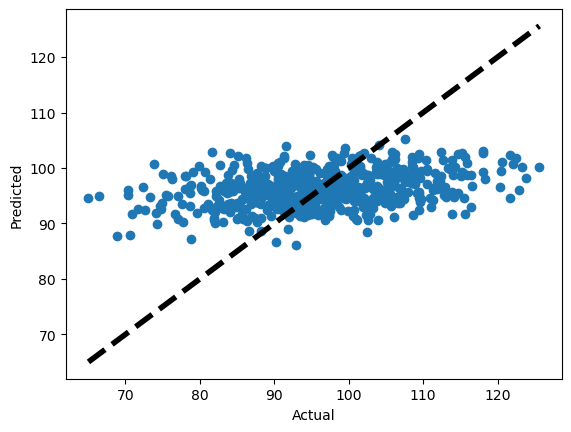

```python
plt.subplots()
plt.scatter(y_test, model4_y)       # showing actual y as X-axis and predicted y as Y-axis
plt.plot([y_test.min(), y_test.max()], [y_test.min(), y_test.max()], 'k--', lw=4)   #dotted line represents perfect prediction (actual = predicted)
plt.xlabel('Actual')
plt.ylabel('Predicted')
plt.show()
```

```python
# select 3 variables
X_new = SelectKBest(f_regression, k=3).fit_transform(X, y)
X_new
```

```
array([[27.44226646,  1.5623365 ,  5.62476647],
       [21.43790121,  2.34415614,  4.61334347],
       [15.24509897,  1.86134536,  3.19252704],
       ...,
       [26.33014636,  2.60543387,  3.49417745],
       [14.47779206,  1.58197228,  6.29134053],
       [14.41981987,  2.30295458,  4.31868985]])
```

```python
# what are those three columns? OBP,SLG,BA are the three columns.
selector = SelectKBest(f_regression, k=3).fit(X, y)
idxs_selected = selector.get_support(indices=True)
print(idxs_selected) # pe_ratio,dividend_yield and eps are better as per f-regression.
```

```
[0 1 5]
```

```python
# split validation (using X_new)

X_train, X_test, y_train, y_test = train_test_split(X_new, y, test_size=0.3, random_state=0)

print(X_train.shape, y_train.shape, X_test.shape, y_test.shape)
```

```
(1326, 3) (1326,) (569, 3) (569,)
```

```python
# Model 5  Building

model5 = lm.LinearRegression()
model5.fit(X_train, y_train)
model5_y = model5.predict(X_test)

# Model Evaluation
print("mean square error: ", mean_squared_error(y_test, model5_y))
print("variance or r-squared: ", explained_variance_score(y_test, model5_y))
```

```
mean square error:  104.32908689379632
variance or r-squared:  0.12287260484981166
```

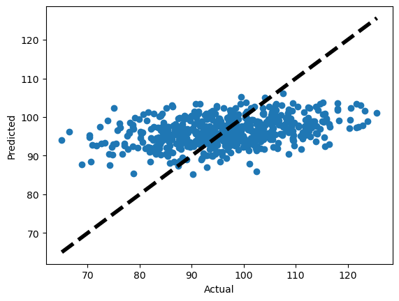

```python
plt.subplots()
plt.scatter(y_test, model5_y)       # showing actual y as X-axis and predicted y as Y-axis
plt.plot([y_test.min(), y_test.max()], [y_test.min(), y_test.max()], 'k--', lw=4)   #dotted line represents perfect prediction (actual = predicted)
plt.xlabel('Actual')
plt.ylabel('Predicted')
plt.show()
```

# Task 7: Model Evaluation

## A. Use metrics like MSE and R-squared to evaluate the model performance on the test set.

```python
#model 1 evaluation
print("mean square error: ", mean_squared_error(y_test, model1_y))
print("variance or r-squared: ", explained_variance_score(y_test, model1_y))
```

[output not shown]

[figure not shown]

```python
plt.subplots()
plt.scatter(y_test, model1_y)       # showing actual y as X-axis and predicted y as Y-axis
plt.plot([y_test.min(), y_test.max()], [y_test.min(), y_test.max()], 'k--', lw=4)   #dotted line represents perfect prediction (actual = predicted)
plt.xlabel('Actual')
plt.ylabel('Predicted')
plt.show()
```

```python
#model 2 evaluation.
print("mean square error: ", mean_squared_error(y_test, model2_y))
print("variance or r-squared: ", explained_variance_score(y_test, model2_y))
```

```
mean square error:  110.43838501225679
variance or r-squared:  0.07149004556392757
```

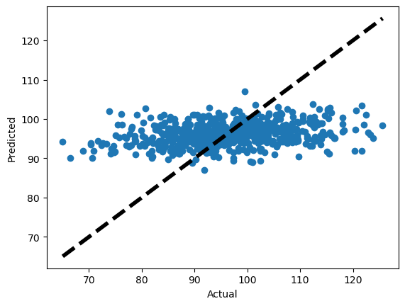

```python
plt.subplots()
plt.scatter(y_test, model2_y)       # showing actual y as X-axis and predicted y as Y-axis
plt.plot([y_test.min(), y_test.max()], [y_test.min(), y_test.max()], 'k--', lw=4)   #dotted line represents perfect prediction (actual = predicted)
plt.xlabel('Actual')
plt.ylabel('Predicted')
plt.show()
```

```python
#model 3 evaluation Lasso.
print("mean square error: ", mean_squared_error(y_test, y_test_pred))
print("variance or r-squared: ", explained_variance_score(y_test, y_test_pred))
```

```
mean square error:  100.05687369557192
variance or r-squared:  0.15878526451161368
```

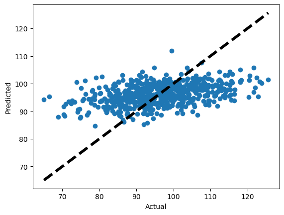

```python
plt.subplots()
plt.scatter(y_test, y_test_pred)       # showing actual y as X-axis and predicted y as Y-axis
plt.plot([y_test.min(), y_test.max()], [y_test.min(), y_test.max()], 'k--', lw=4)   #dotted line represents perfect prediction (actual = predicted)
plt.xlabel('Actual')
plt.ylabel('Predicted')
plt.show()
```

```python
# Model4 Evaluation
print("mean square error: ", mean_squared_error(y_test, model4_y))
print("variance or r-squared: ", explained_variance_score(y_test, model4_y))
```

```
mean square error:  107.17408058935025
variance or r-squared:  0.09892056297672236
```

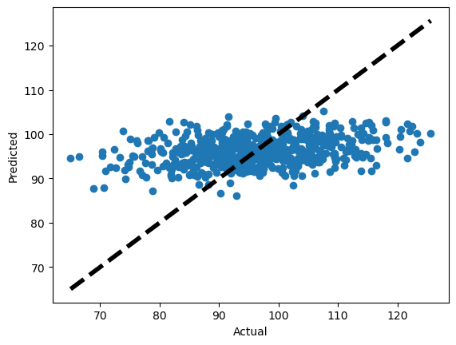

```python
plt.subplots()
plt.scatter(y_test, model4_y)       # showing actual y as X-axis and predicted y as Y-axis
plt.plot([y_test.min(), y_test.max()], [y_test.min(), y_test.max()], 'k--', lw=4)   #dotted line represents perfect prediction (actual = predicted)
plt.xlabel('Actual')
plt.ylabel('Predicted')
plt.show()
```

```python
# Model 5 Evaluation
print("mean square error: ", mean_squared_error(y_test, model5_y))
print("variance or r-squared: ", explained_variance_score(y_test, model5_y))
```

```
mean square error:  104.32908689379632
variance or r-squared:  0.12287260484981166
```

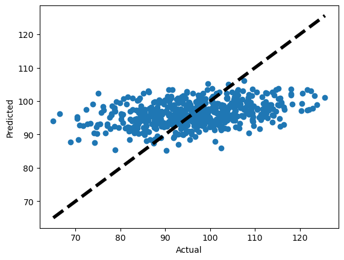

```python
plt.subplots()
plt.scatter(y_test, model5_y)       # showing actual y as X-axis and predicted y as Y-axis
plt.plot([y_test.min(), y_test.max()], [y_test.min(), y_test.max()], 'k--', lw=4)   #dotted line represents perfect prediction (actual = predicted)
plt.xlabel('Actual')
plt.ylabel('Predicted')
plt.show()
```

## B. Compare the performance of different models and identify the best-performing model.

Model 1 - All values

- mean square error: 91.85851109979119
- variance or r-squared: 0.18416942523923763

Model 2 (beta and dividend_ratio)

- mean square error: 110.43838501225679
- variance or r-squared: 0.07149004556392757

Model 3 Lasso

- mean square error: 100.05687369557192
- variance or r-squared: 0.15878526451161368

Model 4 dividend_yield and eps 2 best as per f-regression.

- mean square error: 107.17408058935025
- variance or r-squared: 0.09892056297672236

Model 5 pe_ratio,dividend_yield and eps 3 best as per f-regression

- mean square error: 104.32908689379632
- variance or r-squared: 0.12287260484981166

Model1 > Model3> Model5> Model4>Model2

## C. Which model performed best according to your evaluation metrics?

Model 1 is best according to our evaluation metrics because it low MSE and high r2 comoared to other models

## D. Visualize actual Y vs. predicted Y (from the best-performed model) using a scatter plot

[figure not shown]

```python
# Plotting Actual vs Predicted values
plt.figure(figsize=(10, 6))
plt.subplots()
plt.scatter(y_test, model1_y,c='purple')       # showing actual y as X-axis and predicted y as Y-axis
plt.plot([y_test.min(), y_test.max()], [y_test.min(), y_test.max()], 'k--', lw=4)   #dotted line represents perfect prediction (actual = predicted)
plt.xlabel('Actual')
plt.ylabel('Predicted')
plt.title('Actual vs Predicted stock prices')
plt.grid(True)
plt.show()
```

# Task 8: Interpretation

## A. Interpret the coefficients of the best-performing model to understand the impact of each feature on the stock price.

```python
print('Coefficients: ', model1.coef_)
print("y-intercept ", model1.intercept_) #strong positive coefficient means strong relation with the Y value that is strong price. In our case dividend_yield,beta and eps have strong relation in change of stock market.

#If intercept is a value when all the independent values 0. so the y-intercept of model is better than everyother model.
```

```
Coefficients:  [ 3.20395783e-01  5.00295655e+00  7.50354484e+00  1.38827543e-05
 -1.14983502e-07  2.12354741e+00 -9.57496910e+00  5.10877671e-01
  1.48937436e+00 -1.80077897e+00 -2.70949587e-01 -6.61115049e-01
  7.02127453e-01  5.14039455e-01 -6.99500299e-01  1.44448440e-01
  1.59189961e-02 -4.86585527e-01  4.70666531e-01  9.14880122e-02
 -2.76839803e-01 -2.29888228e-01 -6.05157922e-01  1.02039794e+00]
y-intercept  60.73471751660914
```

```python
X.head()
```

|  | pe_ratio | dividend_yield | beta | market_cap | trading_volume | eps | debt_to_equity | roe | current_ratio | interest_rate | ... | sector_Healthcare | sector_Technology | exchange_AMEX | exchange_NASDAQ | exchange_NYSE | rating_A | rating_AA | rating_AAA | rating_BB | rating_BBB |
| --- | --- | --- | --- | --- | --- | --- | --- | --- | --- | --- | --- | --- | --- | --- | --- | --- | --- | --- | --- | --- | --- |
| 0 | 27.44 | 1.56 | 1.03 | 10120.68 | 1279001.12 | 5.62 | 0.47 | 15.86 | 1.41 | 3.13 | ... | False | False | True | False | False | False | False | False | True | False |
| 1 | 21.44 | 2.34 | 0.85 | 9914.20 | 851882.99 | 4.61 | 0.72 | 15.86 | 1.82 | 2.10 | ... | False | True | False | False | True | False | True | False | False | False |
| 2 | 15.25 | 1.86 | 1.00 | 10842.40 | 850352.01 | 3.19 | 0.33 | 11.97 | 1.80 | 2.84 | ... | False | True | True | False | False | False | False | False | False | True |
| 3 | 24.48 | 1.56 | 1.00 | 8654.20 | 966156.92 | 4.20 | 0.69 | 17.40 | 1.17 | 2.26 | ... | False | False | False | True | False | False | False | False | False | True |
| 4 | 13.47 | 2.33 | 1.07 | 9164.46 | 0.00 | 2.68 | 0.55 | 15.77 | 1.40 | 2.45 | ... | False | False | False | True | False | False | False | True | False | False |

5 rows × 24 columns

## B. What are the most important features according to the regularized model, such as Lasso?

```python
feature_importances = pd.DataFrame(regr.feature_importances_, index = X_train.columns,
                                    columns=['importance']).sort_values('importance', ascending=False)

feature_importances
```

|  | importance |
| --- | --- |
| dividend_yield | 0.12 |
| eps | 0.12 |
| roe | 0.09 |
| pe_ratio | 0.09 |
| beta | 0.09 |
| interest_rate | 0.07 |
| debt_to_equity | 0.07 |
| current_ratio | 0.07 |
| trading_volume | 0.06 |
| gdp_growth | 0.06 |
| market_cap | 0.06 |
| exchange_NASDAQ | 0.01 |
| sector_Consumer | 0.01 |
| rating_AAA | 0.01 |
| exchange_NYSE | 0.01 |
| rating_BBB | 0.01 |
| sector_Energy | 0.01 |
| rating_A | 0.01 |
| rating_AA | 0.01 |
| rating_BB | 0.01 |
| sector_Finance | 0.01 |
| exchange_AMEX | 0.01 |
| sector_Healthcare | 0.01 |
| sector_Technology | 0.01 |

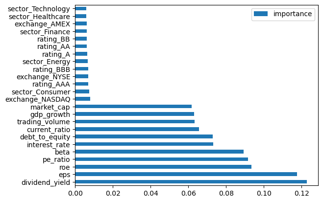

```python
feature_importances.plot(kind='barh');
```

Even According to Lasso the most important features are same as model 1 i.e dividend_yield,beta and eps. And also it has removed many features whose co-efficints like **market_cap, trading_volume, current_ratio, debt_to_equity, gdp_growth,sector_Finance,sector_Technology,exchange_AMEX, rating_A,rating_AA,rating_AAA,and rating_BB** are equal to 0. It is just slightly below model 1 and still can be considered one of the best model for prediction.

```python
print('Coefficients: ', model3.coef_)
print("y-intercept ", model3.intercept_)
```

```
Coefficients:  [ 2.87055217e-01  4.67509670e+00  5.55912375e+00  9.16839657e-06
 -8.86896741e-08  1.94879246e+00 -0.00000000e+00  4.75862998e-01
  0.00000000e+00 -1.55827997e+00 -0.00000000e+00 -0.00000000e+00
  2.27823346e-01  0.00000000e+00 -2.74721275e-01  0.00000000e+00
 -0.00000000e+00 -2.68519446e-01  2.19976039e-01  0.00000000e+00
 -0.00000000e+00 -0.00000000e+00 -0.00000000e+00  8.46086879e-01]
y-intercept  61.633420059615716
```

## C. Discuss the practical implications of your findings.

- By focusing on the most important features and also considering least important features we will be able to do rise assessment, interpret the model, decision making and simultaneously able to give predicted insights.

## D. Suggest areas where additional data could improve the model.

- If we can additional data like company specific data like quarter results,inflation rates, GDP and also time series data so the prediction would improve the model based on my understanding of the model.